# 2.10

Sai Ananthula - emw832

```r
  library("ISLR2")
```

```r
  Boston
```

There are 506 rows and 13 dolumns. The rows represent different suburbs in boston and the columns represent different stats about the suburbs.

```r
  ?Boston
```

```r
  summary(Boston)
```

```
      crim                zn             indus            chas              nox               rm             age              dis              rad              tax           ptratio          lstat            medv
 Min.   : 0.00632   Min.   :  0.00   Min.   : 0.46   Min.   :0.00000   Min.   :0.3850   Min.   :3.561   Min.   :  2.90   Min.   : 1.130   Min.   : 1.000   Min.   :187.0   Min.   :12.60   Min.   : 1.73   Min.   : 5.00
 1st Qu.: 0.08205   1st Qu.:  0.00   1st Qu.: 5.19   1st Qu.:0.00000   1st Qu.:0.4490   1st Qu.:5.886   1st Qu.: 45.02   1st Qu.: 2.100   1st Qu.: 4.000   1st Qu.:279.0   1st Qu.:17.40   1st Qu.: 6.95   1st Qu.:17.02
 Median : 0.25651   Median :  0.00   Median : 9.69   Median :0.00000   Median :0.5380   Median :6.208   Median : 77.50   Median : 3.207   Median : 5.000   Median :330.0   Median :19.05   Median :11.36   Median :21.20
 Mean   : 3.61352   Mean   : 11.36   Mean   :11.14   Mean   :0.06917   Mean   :0.5547   Mean   :6.285   Mean   : 68.57   Mean   : 3.795   Mean   : 9.549   Mean   :408.2   Mean   :18.46   Mean   :12.65   Mean   :22.53
 3rd Qu.: 3.67708   3rd Qu.: 12.50   3rd Qu.:18.10   3rd Qu.:0.00000   3rd Qu.:0.6240   3rd Qu.:6.623   3rd Qu.: 94.08   3rd Qu.: 5.188   3rd Qu.:24.000   3rd Qu.:666.0   3rd Qu.:20.20   3rd Qu.:16.95   3rd Qu.:25.00
 Max.   :88.97620   Max.   :100.00   Max.   :27.74   Max.   :1.00000   Max.   :0.8710   Max.   :8.780   Max.   :100.00   Max.   :12.127   Max.   :24.000   Max.   :711.0   Max.   :22.00   Max.   :37.97   Max.   :50.00
```

Pairwise Scatterplots

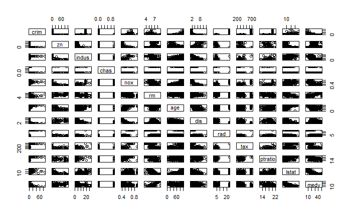

```r
  pairs(Boston)
```

```r
NA
```

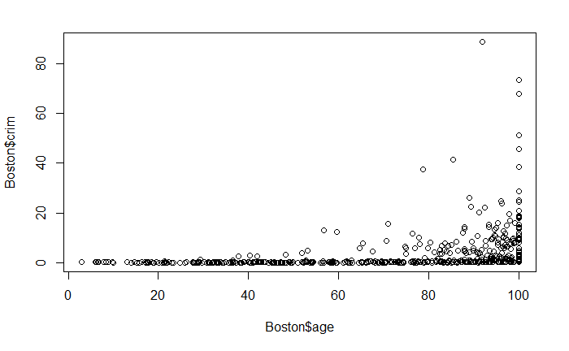

```r
  plot(Boston$age,Boston$crim)
```

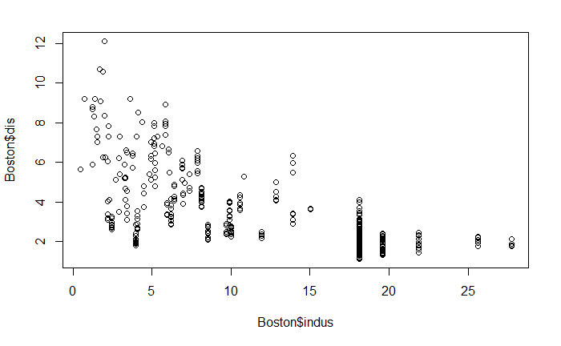

```r
  plot(Boston$indus,Boston$dis)
```

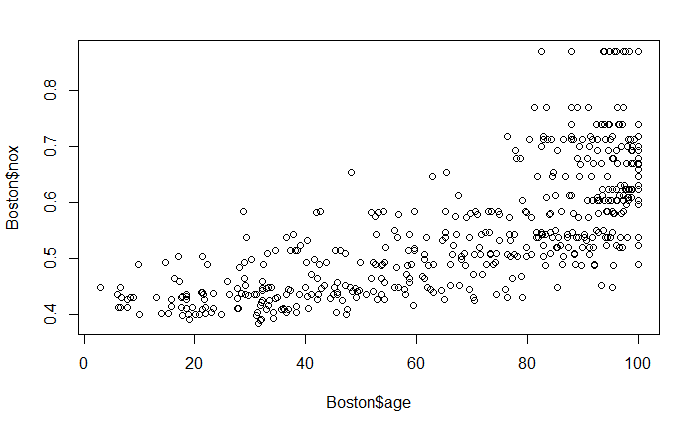

```r
  plot(Boston$age,Boston$nox)
```

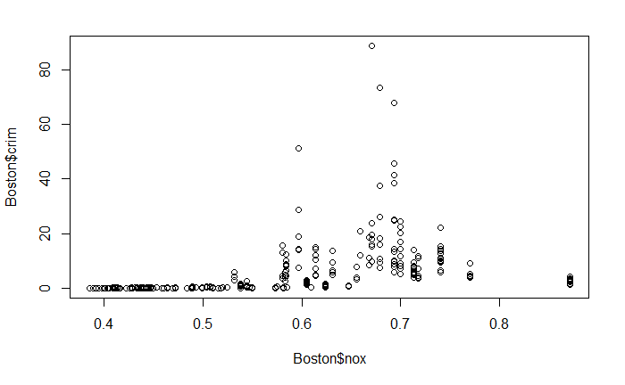

```r
  plot(Boston$nox,Boston$crim)
```

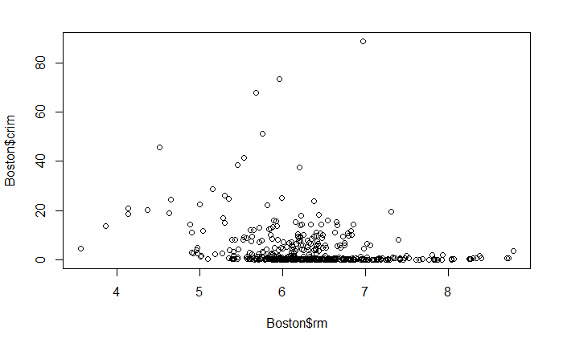

```r
  plot(Boston$rm,Boston$crim)
```

As the age of units built prior to 1940 increases so does the crime rate. The amount of industrial acerage has a negative correlation with distance to employment centers. Thats very interesting since you would assume industrail acerage would house companies that employ tons of people but perhaps the 5 employment centers in the data are not of the industrail nature. As the number of units build prior to 1940 increases so does the nitric oxide concentration. Also, both average number of rooms per dwelling and nitric oxide levels seem to have some correlation with crime rate.

Looking for a relationship between Age of Units and Crime Rate

```r
  crime_age <- lm(Boston$crim~Boston$age)
  summary(crime_age)
```

```
Call:
lm(formula = Boston$crim ~ Boston$age)

Residuals:
   Min     1Q Median     3Q    Max
-6.789 -4.257 -1.230  1.527 82.849

Coefficients:
            Estimate Std. Error t value Pr(>|t|)
(Intercept) -3.77791    0.94398  -4.002 7.22e-05 ***
Boston$age   0.10779    0.01274   8.463 2.85e-16 ***
---
Signif. codes:  0 ‘***’ 0.001 ‘**’ 0.01 ‘*’ 0.05 ‘.’ 0.1 ‘ ’ 1

Residual standard error: 8.057 on 504 degrees of freedom
Multiple R-squared:  0.1244,    Adjusted R-squared:  0.1227
F-statistic: 71.62 on 1 and 504 DF,  p-value: 2.855e-16
```

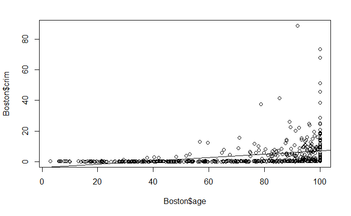

```r
  plot(Boston$age, Boston$crim)
  abline(crime_age)
```

The summary does indicate some sort of relationship due to values of p-value and f-stat but the problem is the multiple r-squared value is very low. Also, a quick glance at the chart shows the line passes through a good chunk of the data but the function is probably not linear

```r
  crime_rm <- lm(Boston$crim~Boston$rm)
  summary(crime_rm)
```

```
Call:
lm(formula = Boston$crim ~ Boston$rm)

Residuals:
   Min     1Q Median     3Q    Max
-6.604 -3.952 -2.654  0.989 87.197

Coefficients:
            Estimate Std. Error t value Pr(>|t|)
(Intercept)   20.482      3.365   6.088 2.27e-09 ***
Boston$rm     -2.684      0.532  -5.045 6.35e-07 ***
---
Signif. codes:  0 ‘***’ 0.001 ‘**’ 0.01 ‘*’ 0.05 ‘.’ 0.1 ‘ ’ 1

Residual standard error: 8.401 on 504 degrees of freedom
Multiple R-squared:  0.04807,   Adjusted R-squared:  0.04618
F-statistic: 25.45 on 1 and 504 DF,  p-value: 6.347e-07
```

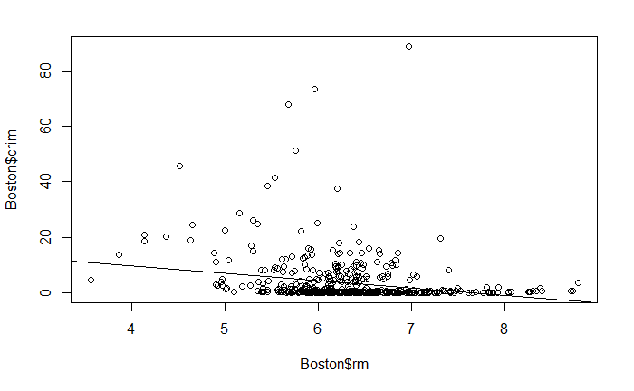

```r
  plot(Boston$rm, Boston$crim)
  abline(crime_rm)
```

The summary does indicate some sort of relationship due to the highly signicant p-value but the function “fits” the data very poorly. In all likelyhood there is a relationship but is of the non-linear variety.

```r
  crime_nox <- lm(Boston$crim~Boston$nox)
  summary(crime_nox)
```

```
Call:
lm(formula = Boston$crim ~ Boston$nox)

Residuals:
    Min      1Q  Median      3Q     Max
-12.371  -2.738  -0.974   0.559  81.728

Coefficients:
            Estimate Std. Error t value Pr(>|t|)
(Intercept)  -13.720      1.699  -8.073 5.08e-15 ***
Boston$nox    31.249      2.999  10.419  < 2e-16 ***
---
Signif. codes:  0 ‘***’ 0.001 ‘**’ 0.01 ‘*’ 0.05 ‘.’ 0.1 ‘ ’ 1

Residual standard error: 7.81 on 504 degrees of freedom
Multiple R-squared:  0.1772,    Adjusted R-squared:  0.1756
F-statistic: 108.6 on 1 and 504 DF,  p-value: < 2.2e-16
```

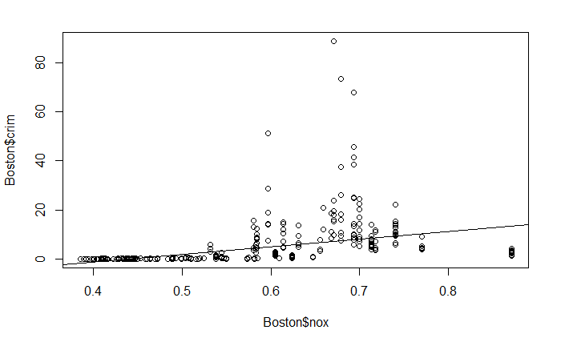

```r
  plot(Boston$nox, Boston$crim)
  abline(crime_nox)
```

The summary does indicate some sort of relationship due to the highly signicant p-value but the function “fits” the data very poorly. In all likelyhood there is a relationship but is of the non-linear variety.

Amount of Units built prior to 1940, nitric oxide concentration, and avg number of rooms per dwelling all seem to have some impact of crime rates. The amount of old units relationship to crime rate seems to somewhat linear but most likely still is curved. Both nitrix oxide and avg number of rooms seem to have a almost quadratic relation to crime rate.

```r
  summary(Boston)
```

```
      crim                zn             indus            chas              nox               rm             age              dis              rad              tax           ptratio          lstat            medv
 Min.   : 0.00632   Min.   :  0.00   Min.   : 0.46   Min.   :0.00000   Min.   :0.3850   Min.   :3.561   Min.   :  2.90   Min.   : 1.130   Min.   : 1.000   Min.   :187.0   Min.   :12.60   Min.   : 1.73   Min.   : 5.00
 1st Qu.: 0.08205   1st Qu.:  0.00   1st Qu.: 5.19   1st Qu.:0.00000   1st Qu.:0.4490   1st Qu.:5.886   1st Qu.: 45.02   1st Qu.: 2.100   1st Qu.: 4.000   1st Qu.:279.0   1st Qu.:17.40   1st Qu.: 6.95   1st Qu.:17.02
 Median : 0.25651   Median :  0.00   Median : 9.69   Median :0.00000   Median :0.5380   Median :6.208   Median : 77.50   Median : 3.207   Median : 5.000   Median :330.0   Median :19.05   Median :11.36   Median :21.20
 Mean   : 3.61352   Mean   : 11.36   Mean   :11.14   Mean   :0.06917   Mean   :0.5547   Mean   :6.285   Mean   : 68.57   Mean   : 3.795   Mean   : 9.549   Mean   :408.2   Mean   :18.46   Mean   :12.65   Mean   :22.53
 3rd Qu.: 3.67708   3rd Qu.: 12.50   3rd Qu.:18.10   3rd Qu.:0.00000   3rd Qu.:0.6240   3rd Qu.:6.623   3rd Qu.: 94.08   3rd Qu.: 5.188   3rd Qu.:24.000   3rd Qu.:666.0   3rd Qu.:20.20   3rd Qu.:16.95   3rd Qu.:25.00
 Max.   :88.97620   Max.   :100.00   Max.   :27.74   Max.   :1.00000   Max.   :0.8710   Max.   :8.780   Max.   :100.00   Max.   :12.127   Max.   :24.000   Max.   :711.0   Max.   :22.00   Max.   :37.97   Max.   :50.00
```

Areas with High Crime Rates

```r
  high_crime <- subset(Boston, Boston$crim > 3.5)
  print(high_crime)
```

|  | crim | zn | indus | chas | nox | rm | age | dis | rad | tax | ptratio | lstat | medv |
| --- | --- | --- | --- | --- | --- | --- | --- | --- | --- | --- | --- | --- | --- |
| 144 | 4.09740 | 0 | 19.58 | 0 | 0.871 | 5.468 | 100.0 | 1.4118 | 5 | 403 | 14.7 | 26.42 | 15.6 |
| 156 | 3.53501 | 0 | 19.58 | 1 | 0.871 | 6.152 | 82.6 | 1.7455 | 5 | 403 | 14.7 | 15.02 | 15.6 |
| 357 | 8.98296 | 0 | 18.10 | 1 | 0.770 | 6.212 | 97.4 | 2.1222 | 24 | 666 | 20.2 | 17.60 | 17.8 |
| 358 | 3.84970 | 0 | 18.10 | 1 | 0.770 | 6.395 | 91.0 | 2.5052 | 24 | 666 | 20.2 | 13.27 | 21.7 |
| 359 | 5.20177 | 0 | 18.10 | 1 | 0.770 | 6.127 | 83.4 | 2.7227 | 24 | 666 | 20.2 | 11.48 | 22.7 |
| 360 | 4.26131 | 0 | 18.10 | 0 | 0.770 | 6.112 | 81.3 | 2.5091 | 24 | 666 | 20.2 | 12.67 | 22.6 |
| 361 | 4.54192 | 0 | 18.10 | 0 | 0.770 | 6.398 | 88.0 | 2.5182 | 24 | 666 | 20.2 | 7.79 | 25.0 |
| 362 | 3.83684 | 0 | 18.10 | 0 | 0.770 | 6.251 | 91.1 | 2.2955 | 24 | 666 | 20.2 | 14.19 | 19.9 |
| 363 | 3.67822 | 0 | 18.10 | 0 | 0.770 | 5.362 | 96.2 | 2.1036 | 24 | 666 | 20.2 | 10.19 | 20.8 |
| 364 | 4.22239 | 0 | 18.10 | 1 | 0.770 | 5.803 | 89.0 | 1.9047 | 24 | 666 | 20.2 | 14.64 | 16.8 |

[output cut: 120 more lines]

The range of crime rates if from .00632 to 88.9762.

Areas with High Tax Rates

```r
  high_tax <- subset(Boston, Boston$tax > 666)
  print(high_tax)
```

|  | crim | zn | indus | chas | nox | rm | age | dis | rad | tax | ptratio | lstat | medv |
| --- | --- | --- | --- | --- | --- | --- | --- | --- | --- | --- | --- | --- | --- |
| 489 | 0.15086 | 0 | 27.74 | 0 | 0.609 | 5.454 | 92.7 | 1.8209 | 4 | 711 | 20.1 | 18.06 | 15.2 |
| 490 | 0.18337 | 0 | 27.74 | 0 | 0.609 | 5.414 | 98.3 | 1.7554 | 4 | 711 | 20.1 | 23.97 | 7.0 |
| 491 | 0.20746 | 0 | 27.74 | 0 | 0.609 | 5.093 | 98.0 | 1.8226 | 4 | 711 | 20.1 | 29.68 | 8.1 |
| 492 | 0.10574 | 0 | 27.74 | 0 | 0.609 | 5.983 | 98.8 | 1.8681 | 4 | 711 | 20.1 | 18.07 | 13.6 |
| 493 | 0.11132 | 0 | 27.74 | 0 | 0.609 | 5.983 | 83.5 | 2.1099 | 4 | 711 | 20.1 | 13.35 | 20.1 |

Areas with Pupil:Teacher Ratios

```r
  high_pt <- subset(Boston, Boston$ptratio > 20.2)
  print(high_pt)
```

|  | crim | zn | indus | chas | nox | rm | age | dis | rad | tax | ptratio | lstat | medv |
| --- | --- | --- | --- | --- | --- | --- | --- | --- | --- | --- | --- | --- | --- |
| 14 | 0.62976 | 0 | 8.14 | 0 | 0.538 | 5.949 | 61.8 | 4.7075 | 4 | 307 | 21.0 | 8.26 | 20.4 |
| 15 | 0.63796 | 0 | 8.14 | 0 | 0.538 | 6.096 | 84.5 | 4.4619 | 4 | 307 | 21.0 | 10.26 | 18.2 |
| 16 | 0.62739 | 0 | 8.14 | 0 | 0.538 | 5.834 | 56.5 | 4.4986 | 4 | 307 | 21.0 | 8.47 | 19.9 |
| 17 | 1.05393 | 0 | 8.14 | 0 | 0.538 | 5.935 | 29.3 | 4.4986 | 4 | 307 | 21.0 | 6.58 | 23.1 |
| 18 | 0.78420 | 0 | 8.14 | 0 | 0.538 | 5.990 | 81.7 | 4.2579 | 4 | 307 | 21.0 | 14.67 | 17.5 |
| 19 | 0.80271 | 0 | 8.14 | 0 | 0.538 | 5.456 | 36.6 | 3.7965 | 4 | 307 | 21.0 | 11.69 | 20.2 |
| 20 | 0.72580 | 0 | 8.14 | 0 | 0.538 | 5.727 | 69.5 | 3.7965 | 4 | 307 | 21.0 | 11.28 | 18.2 |
| 21 | 1.25179 | 0 | 8.14 | 0 | 0.538 | 5.570 | 98.1 | 3.7979 | 4 | 307 | 21.0 | 21.02 | 13.6 |
| 22 | 0.85204 | 0 | 8.14 | 0 | 0.538 | 5.965 | 89.2 | 4.0123 | 4 | 307 | 21.0 | 13.83 | 19.6 |
| 23 | 1.23247 | 0 | 8.14 | 0 | 0.538 | 6.142 | 91.7 | 3.9769 | 4 | 307 | 21.0 | 18.72 | 15.2 |

[output cut: 46 more lines]

Areas that border the Charles river

```r
  river_side <- subset(Boston, Boston$chas == 1)
  print(river_side)
```

|  | crim | zn | indus | chas | nox | rm | age | dis | rad | tax | ptratio | lstat | medv |
| --- | --- | --- | --- | --- | --- | --- | --- | --- | --- | --- | --- | --- | --- |
| 143 | 3.32105 | 0 | 19.58 | 1 | 0.8710 | 5.403 | 100.0 | 1.3216 | 5 | 403 | 14.7 | 26.82 | 13.4 |
| 153 | 1.12658 | 0 | 19.58 | 1 | 0.8710 | 5.012 | 88.0 | 1.6102 | 5 | 403 | 14.7 | 12.12 | 15.3 |
| 155 | 1.41385 | 0 | 19.58 | 1 | 0.8710 | 6.129 | 96.0 | 1.7494 | 5 | 403 | 14.7 | 15.12 | 17.0 |
| 156 | 3.53501 | 0 | 19.58 | 1 | 0.8710 | 6.152 | 82.6 | 1.7455 | 5 | 403 | 14.7 | 15.02 | 15.6 |
| 161 | 1.27346 | 0 | 19.58 | 1 | 0.6050 | 6.250 | 92.6 | 1.7984 | 5 | 403 | 14.7 | 5.50 | 27.0 |
| 163 | 1.83377 | 0 | 19.58 | 1 | 0.6050 | 7.802 | 98.2 | 2.0407 | 5 | 403 | 14.7 | 1.92 | 50.0 |
| 164 | 1.51902 | 0 | 19.58 | 1 | 0.6050 | 8.375 | 93.9 | 2.1620 | 5 | 403 | 14.7 | 3.32 | 50.0 |
| 209 | 0.13587 | 0 | 10.59 | 1 | 0.4890 | 6.064 | 59.1 | 4.2392 | 4 | 277 | 18.6 | 14.66 | 24.4 |
| 210 | 0.43571 | 0 | 10.59 | 1 | 0.4890 | 5.344 | 100.0 | 3.8750 | 4 | 277 | 18.6 | 23.09 | 20.0 |
| 211 | 0.17446 | 0 | 10.59 | 1 | 0.4890 | 5.960 | 92.1 | 3.8771 | 4 | 277 | 18.6 | 17.27 | 21.7 |

[output cut: 25 more lines]

There are 35 suburbs that bound the Charles river.

```r
  summary(Boston)
```

```
      crim                zn             indus            chas              nox               rm             age              dis              rad              tax           ptratio          lstat            medv
 Min.   : 0.00632   Min.   :  0.00   Min.   : 0.46   Min.   :0.00000   Min.   :0.3850   Min.   :3.561   Min.   :  2.90   Min.   : 1.130   Min.   : 1.000   Min.   :187.0   Min.   :12.60   Min.   : 1.73   Min.   : 5.00
 1st Qu.: 0.08205   1st Qu.:  0.00   1st Qu.: 5.19   1st Qu.:0.00000   1st Qu.:0.4490   1st Qu.:5.886   1st Qu.: 45.02   1st Qu.: 2.100   1st Qu.: 4.000   1st Qu.:279.0   1st Qu.:17.40   1st Qu.: 6.95   1st Qu.:17.02
 Median : 0.25651   Median :  0.00   Median : 9.69   Median :0.00000   Median :0.5380   Median :6.208   Median : 77.50   Median : 3.207   Median : 5.000   Median :330.0   Median :19.05   Median :11.36   Median :21.20
 Mean   : 3.61352   Mean   : 11.36   Mean   :11.14   Mean   :0.06917   Mean   :0.5547   Mean   :6.285   Mean   : 68.57   Mean   : 3.795   Mean   : 9.549   Mean   :408.2   Mean   :18.46   Mean   :12.65   Mean   :22.53
 3rd Qu.: 3.67708   3rd Qu.: 12.50   3rd Qu.:18.10   3rd Qu.:0.00000   3rd Qu.:0.6240   3rd Qu.:6.623   3rd Qu.: 94.08   3rd Qu.: 5.188   3rd Qu.:24.000   3rd Qu.:666.0   3rd Qu.:20.20   3rd Qu.:16.95   3rd Qu.:25.00
 Max.   :88.97620   Max.   :100.00   Max.   :27.74   Max.   :1.00000   Max.   :0.8710   Max.   :8.780   Max.   :100.00   Max.   :12.127   Max.   :24.000   Max.   :711.0   Max.   :22.00   Max.   :37.97   Max.   :50.00
```

The median pupil:teacher ratio is 19.05.

Areas with Lowest Home Value

```r
    lowest <- subset(Boston, Boston$medv == 5)
    print(lowest)
```

|  | crim | zn | indus | chas | nox | rm | age | dis | rad | tax | ptratio | lstat | medv |
| --- | --- | --- | --- | --- | --- | --- | --- | --- | --- | --- | --- | --- | --- |
| 399 | 38.3518 | 0 | 18.1 | 0 | 0.693 | 5.453 | 100 | 1.4896 | 24 | 666 | 20.2 | 30.59 | 5 |
| 406 | 67.9208 | 0 | 18.1 | 0 | 0.693 | 5.683 | 100 | 1.4254 | 24 | 666 | 20.2 | 22.98 | 5 |

Both of the areas with lowest home values have extremely higher crime rates as well as identaical percentages of land with industrail use. They both have the same nitrogen oxside concentration and percentage of units that were build before 1940. Their predictors across the board are either equal or within in spitting distance of each other. This leads me to include if they are so similar they most likely are next to each other.

```r
  rooms <- subset(Boston, Boston$rm > 7)
  print(rooms)
```

|  | crim | zn | indus | chas | nox | rm | age | dis | rad | tax | ptratio | lstat | medv |
| --- | --- | --- | --- | --- | --- | --- | --- | --- | --- | --- | --- | --- | --- |
| 3 | 0.02729 | 0.0 | 7.07 | 0 | 0.4690 | 7.185 | 61.1 | 4.9671 | 2 | 242 | 17.8 | 4.03 | 34.7 |
| 5 | 0.06905 | 0.0 | 2.18 | 0 | 0.4580 | 7.147 | 54.2 | 6.0622 | 3 | 222 | 18.7 | 5.33 | 36.2 |
| 41 | 0.03359 | 75.0 | 2.95 | 0 | 0.4280 | 7.024 | 15.8 | 5.4011 | 3 | 252 | 18.3 | 1.98 | 34.9 |
| 56 | 0.01311 | 90.0 | 1.22 | 0 | 0.4030 | 7.249 | 21.9 | 8.6966 | 5 | 226 | 17.9 | 4.81 | 35.4 |
| 65 | 0.01951 | 17.5 | 1.38 | 0 | 0.4161 | 7.104 | 59.5 | 9.2229 | 3 | 216 | 18.6 | 8.05 | 33.0 |
| 89 | 0.05660 | 0.0 | 3.41 | 0 | 0.4890 | 7.007 | 86.3 | 3.4217 | 2 | 270 | 17.8 | 5.50 | 23.6 |
| 90 | 0.05302 | 0.0 | 3.41 | 0 | 0.4890 | 7.079 | 63.1 | 3.4145 | 2 | 270 | 17.8 | 5.70 | 28.7 |
| 98 | 0.12083 | 0.0 | 2.89 | 0 | 0.4450 | 8.069 | 76.0 | 3.4952 | 2 | 276 | 18.0 | 4.21 | 38.7 |
| 99 | 0.08187 | 0.0 | 2.89 | 0 | 0.4450 | 7.820 | 36.9 | 3.4952 | 2 | 276 | 18.0 | 3.57 | 43.8 |
| 100 | 0.06860 | 0.0 | 2.89 | 0 | 0.4450 | 7.416 | 62.5 | 3.4952 | 2 | 276 | 18.0 | 6.19 | 33.2 |

[output cut: 54 more lines]

```r
  room_8 <- subset(Boston, Boston$rm > 8)
  print(room_8)
```

|  | crim | zn | indus | chas | nox | rm | age | dis | rad | tax | ptratio | lstat | medv |
| --- | --- | --- | --- | --- | --- | --- | --- | --- | --- | --- | --- | --- | --- |
| 98 | 0.12083 | 0 | 2.89 | 0 | 0.4450 | 8.069 | 76.0 | 3.4952 | 2 | 276 | 18.0 | 4.21 | 38.7 |
| 164 | 1.51902 | 0 | 19.58 | 1 | 0.6050 | 8.375 | 93.9 | 2.1620 | 5 | 403 | 14.7 | 3.32 | 50.0 |
| 205 | 0.02009 | 95 | 2.68 | 0 | 0.4161 | 8.034 | 31.9 | 5.1180 | 4 | 224 | 14.7 | 2.88 | 50.0 |
| 225 | 0.31533 | 0 | 6.20 | 0 | 0.5040 | 8.266 | 78.3 | 2.8944 | 8 | 307 | 17.4 | 4.14 | 44.8 |
| 226 | 0.52693 | 0 | 6.20 | 0 | 0.5040 | 8.725 | 83.0 | 2.8944 | 8 | 307 | 17.4 | 4.63 | 50.0 |
| 227 | 0.38214 | 0 | 6.20 | 0 | 0.5040 | 8.040 | 86.5 | 3.2157 | 8 | 307 | 17.4 | 3.13 | 37.6 |
| 233 | 0.57529 | 0 | 6.20 | 0 | 0.5070 | 8.337 | 73.3 | 3.8384 | 8 | 307 | 17.4 | 2.47 | 41.7 |
| 234 | 0.33147 | 0 | 6.20 | 0 | 0.5070 | 8.247 | 70.4 | 3.6519 | 8 | 307 | 17.4 | 3.95 | 48.3 |
| 254 | 0.36894 | 22 | 5.86 | 0 | 0.4310 | 8.259 | 8.4 | 8.9067 | 7 | 330 | 19.1 | 3.54 | 42.8 |
| 258 | 0.61154 | 20 | 3.97 | 0 | 0.6470 | 8.704 | 86.9 | 1.8010 | 5 | 264 | 13.0 | 5.12 | 50.0 |

[output cut: 3 more lines]